# R Notebook

## Mise en place - Getting your workspace ready

Load the igraph package

```r
# load igraph
library(igraph)
library(centiserve)
library(tidyverse)
```

# Create Graph Object

## This is the twitter network of users. Users are connected if there RT or reply or a quote tweet.

### Read data file

```r
#read file in as members
mt_edgelist <- read.csv("../data cleaning/people-edge-list.csv")
View(mt_edgelist)
head(mt_edgelist)
```

|  | X | Sender | Receiver | text | created_at | sourcetweet_text | Self.organization | Building.community | Broadening.the.counterpublic | Creating.change.in.math | SJEDI | bipoc | gender | lgbtq | talk.support | amplification | influencers | representation | thankful | emotional.support | BC.impact | SO.impact | hashtags | indigenous | advocacy | CC.impact | SJEDI.impact | belonging | learning | … |
| --- | --- | --- | --- | --- | --- | --- | --- | --- | --- | --- | --- | --- | --- | --- | --- | --- | --- | --- | --- | --- | --- | --- | --- | --- | --- | --- | --- | --- | --- | --- |
| 1 | 3 | mathprofcarrie | WanderingPoint | @WanderingPoint @xl772 @pwr2dppl Here!!! #disruptJMM you go @xl772 | 2020-01-16T17:02:17.000Z | NA | False | True | False | False | False | False | False | False | True | False | False | False | False | True | False | False | False | False | False | False | False | False | False | … |
| 2 | 4 | mathprofcarrie | xl772 | @xl772 @pwr2dppl Where and what? - let's get the #disruptJMM folks to support! | 2020-01-16T16:53:06.000Z | NA | False | True | False | False | False | False | False | False | True | False | False | False | False | False | True | False | False | False | False | False | False | False | False | … |
| 3 | 8 | LoboWithACause | MarissaKawehi | Seriosly, taking pictures while accurately and succinctly summarizing important and key points with appropriate tags is task that takes amazing skill and love! Thank you all so much not only for my se… | 2020-01-16T14:14:35.000Z | Very happy for folks like @mathyadriana @monsoon0 @thewordninja_bk @pwr2dppl @fra_berni and others for live tweeting @LoboWithACause's talk at #JMM! Thanks everyone and please keep sharing the #Disrup… | True | True | False | False | False | False | False | False | True | True | False | False | True | False | False | False | False | False | False | False | False | False | False | … |
| 4 | 13 | RachelleDeCoste | LoboWithACause | @LoboWithACause Thank you for sharing this this morning. I was definitely challenged to think about what inclusion means in a different way. I appreciate that challenge and will take it home with me. … | 2020-01-16T03:18:23.000Z | NA | True | True | False | True | True | False | False | False | False | False | False | False | True | False | False | True | False | False | False | True | True | False | False | … |
| 5 | 17 | RachelleDeCoste | mathprofcarrie | Thank you for organizing this. There were so many important points made and I have many things to think about. #disruptjmm https://t.co/l0zFMsjLb6 | 2020-01-15T17:21:11.000Z | #DisruptJMM what does it mean when we say that we need to welcome marginalized communities into our community? The subtext is that they are not already part of the community...@LoboWithACause #JMM2020 | True | True | False | False | True | False | False | False | False | True | False | False | True | False | False | False | False | False | False | False | False | False | True | … |
| 6 | 18 | monsoon0 | monsoon0 | I didn’t expect to be facing my own sense of not-belonging so quickly and so deeply in this #DisruptJMM session... @JointMath | 2020-01-15T17:17:58.000Z | NA | False | True | True | False | False | False | False | False | False | False | True | False | False | False | False | False | False | False | False | False | False | True | False | … |

Note: the sender is in the first column and receiver in the second

```r
#create a matrix, just of Sender and Receiver
send_interact <- cbind(Sender = mt_edgelist$Sender,Interactor = mt_edgelist$Receiver)

# check it out
head(send_interact)
```

```
##      Sender            Interactor
## [1,] "mathprofcarrie"  "WanderingPoint"
## [2,] "mathprofcarrie"  "xl772"
## [3,] "LoboWithACause"  "MarissaKawehi"
## [4,] "RachelleDeCoste" "LoboWithACause"
## [5,] "RachelleDeCoste" "mathprofcarrie"
## [6,] "monsoon0"        "monsoon0"
```

```r
dim(send_interact)
```

```
## [1] 959   2
```

### Define network from edgelist

```r
# make a graph object
mathpeeps.g <- graph.edgelist(send_interact, directed = TRUE)
```

### Visualize the group network

Use the igraph documentation @igraph to comment what the code below is doing:

- [layout_with_fr]{https://igraph.org/r/doc/layout_with_fr.html}
- [edge_attr]{https://igraph.org/r/doc/edge_attr.html} Then run the following code & revise your code as necessary.

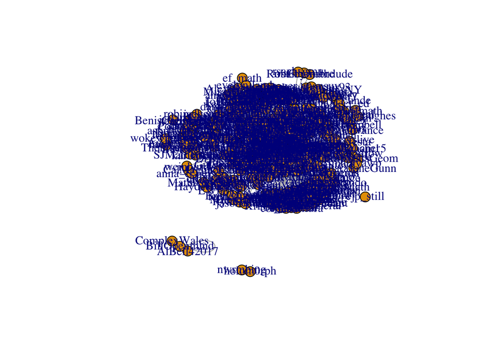

```r
#plot features
la <- layout_with_fr(mathpeeps.g)
e.wt <- edge_attr(mathpeeps.g, "weight")

#plot group network
plot(mathpeeps.g, layout=la, vertex.size=10,edge.width=e.wt,vertex.label=V(mathpeeps.g)$name, edge.arrow.size = .2)
```

```r
png("people.png", width = 465, height = 225, units='mm', res = 300)
plot(mathpeeps.g, layout=la, vertex.size=2,edge.width=e.wt,vertex.label=V(mathpeeps.g)$name, edge.arrow.size = .2)
dev.off()
```

### Network Statistics

Degree exploration

```r
#Degree of top 10 in order
deg.peeps <- degree(mathpeeps.g,  mode = "all",
  loops = FALSE,
  normalized = FALSE)
names(deg.peeps) <- V(mathpeeps.g)$name
ind <- order(-deg.peeps)
deg.peeps[ind][1:50]
```

```
##  mathprofcarrie        pwr2dppl  WanderingPoint         sbagley       JointMath
##             210             154             138             115              85
##  LoboWithACause  VictorPiercey1          RG1gal   MarissaKawehi    mathyadriana
##              62              46              40              39              31
##        monsoon0          DrMRLD mathillustrated benjamindickman      wizard2048
##              29              23              22              22              21
##    blkmathmagic       frontLahn           xl772  matthematician   ClaudioJacobo
##              20              18              17              17              17
##       siwelwerd      kmkinnaird         MBarany       fra_berni         KJMDPhD
##              16              16              15              14              12
##    MattBoelkins   diazlopezmath  qsideinstitute   belladoesmath          dtkung
##              11              10              10              10               9
##    maryepilgrim         twistor      AliciaPL25 thewordninja_bk  Shelby_M_Scott
##               9               9               9               8               8
##    mathcourtney         blviray       HthrLynnJ  FedericoArdila      joshlaison
##               8               8               7               7               7
##       katebelin  DrHenryGarrett BarbaraFantechi RachelleDeCoste DrClaireJanelle
##               7               7               7               6               6
##  elizabethmunch susan_dagostino      drspoulsen     darrenglass   GizemKaraali_
##               6               6               6               6               6
```

```r
#Degree of top 10 in order
indeg.peeps <- degree(mathpeeps.g,  mode = "in",
  loops = FALSE,
  normalized = FALSE)
names(indeg.peeps) <- V(mathpeeps.g)$name
ind <- order(-indeg.peeps)
top_indeg_peeps <- indeg.peeps[ind][1:10]
print(top_indeg_peeps)
```

```
## WanderingPoint mathprofcarrie        sbagley       pwr2dppl         RG1gal
##            129            117             93             80             38
## VictorPiercey1  MarissaKawehi       monsoon0   mathyadriana LoboWithACause
##             36             30             26             23             22
```

```r
#Out degree of top 10 in order
outdeg.peeps <- degree(mathpeeps.g,  mode = "out",
  loops = FALSE,
  normalized = FALSE)
names(outdeg.peeps) <- V(mathpeeps.g)$name
ind <- order(-outdeg.peeps)
top_outdeg_peeps <- outdeg.peeps[ind][1:10]
print(top_outdeg_peeps)
```

```
##  mathprofcarrie       JointMath        pwr2dppl  LoboWithACause         sbagley
##              93              85              74              40              22
##      wizard2048      kmkinnaird benjamindickman           xl772  VictorPiercey1
##              21              16              11              10              10
```

```r
#Get indeg rank + outdeg rank
people <- data.frame(deg.peeps)
people$totalrank[order(-people$deg.peeps)] <- 1:nrow(people)
people$indeg <- degree(mathpeeps.g,  mode = "in",
  loops = FALSE,
  normalized = FALSE)
people$outdeg <- degree(mathpeeps.g,  mode = "out",
  loops = FALSE,
  normalized = FALSE)
people$inrank[order(people$indeg,decreasing=TRUE)] <- 1:nrow(people)
people$outrank[order(people$outdeg,decreasing=TRUE)] <- 1:nrow(people)
people$ranksum <- people$inrank+people$outrank
people$ranksumrank[order(people$ranksum)] <- 1:nrow(people)
print(people[order(people$ranksumrank), ])
```

```
##                 deg.peeps totalrank indeg outdeg inrank outrank ranksum
## mathprofcarrie        210         1   117     93      2       1       3
## pwr2dppl              154         2    80     74      4       3       7
## sbagley               115         4    93     22      3       5       8
## WanderingPoint        138         3   129      9      1      12      13
## LoboWithACause         62         6    22     40     10       4      14
## VictorPiercey1         46         7    36     10      6      10      16
## MarissaKawehi          39         9    30      9      7      13      20
## mathyadriana           31        10    23      8      9      16      25
## benjamindickman        22        14    11     11     19       8      27
## mathillustrated        22        13    12     10     18      11      29
## blkmathmagic           20        16    14      6     13      20      33
## xl772                  17        18     7     10     26       9      35
## frontLahn              18        17    13      5     16      25      41
## MBarany                15        23     6      9     29      14      43
## matthematician         17        19    13      4     14      33      47
## monsoon0               29        11    26      3      8      43      51
## MattBoelkins           11        26     5      6     33      19      52
## siwelwerd              16        21    13      3     15      45      60
## thewordninja_bk         8        34     4      4     39      32      71
## RG1gal                 40         8    38      2      5      67      72
## DrMRLD                 23        12    21      2     11      63      74
## diazlopezmath          10        27     7      3     27      48      75
## wizard2048             21        15     0     21     69       6      75
## maryepilgrim            9        31     1      8     59      17      76
## kmkinnaird             16        22     0     16     70       7      77
## fra_berni              14        24    12      2     17      61      78
## DrHenryGarrett          7        42     1      6     57      21      78
## JointMath              85         5     0     85     76       2      78
## Shelby_M_Scott          8        35     5      3     36      46      82
## KJMDPhD                12        25    10      2     20      64      84
## elizabethmunch          6        46     2      4     51      35      86
## BikeMath                5        51     2      3     43      44      87
## SuzanneSindi            5        52     0      5     68      24      92
## HthrLynnJ               7        38     5      2     32      62      94
## RachelleDeCoste         6        44     4      2     38      60      98
## FedericoArdila          7        39     5      2     34      65      99
## joshlaison              7        40     5      2     35      66     101
## SoledadVillar5          4        60     1      3     56      47     103
## numberdance             5        53     0      5     80      26     106
```

[output cut: 589 more lines]

```
## AJ72826261              307
## jasonemiller            308
## JessieLenarz            309
## JasonWilliamsNY         310
## suburbanlion            311
## ONUMathStat             312
## BrandauerJ              313
## daveinstpaul            314
## cjp_still               315
## topolojack              316
## superyarn               317
## dbdoughe                318
## cordesm                 319
## f_futamura              320
## noellebeckman           321
```

The high degree of RG1gal comes from people mentioning her, which makes sense - one of the most frequently used codes was around humanizing & so she was tagged/replied to multiple times [38], but only tweeted 2x.

Interesting that JointMath has the second highest Twitter outdegree. Do they autoretweet everything that they are tagged in?

```r
#Careful, this overcounts!  The 'text' field is truncated for retweets, need to load
#new data file that includes sourcetweet_text field
JointMath<-mt_edgelist[mt_edgelist$Sender == 'JointMath',]
#did not use any of the hashtags or did not include a @JointMath tag
NotHT20<-subset(JointMath, !grepl("#JMM2020", JointMath$sourcetweet_text ), )
NotHT<-subset(NotHT20, !grepl("#JMM2021", NotHT20$sourcetweet_text ), )
Notpinged<-subset(NotHT, !grepl("@JointMath", NotHT$sourcetweet_text ))

# for example - this has nothing that says RT me...
Notpinged$text[12]
```

```
## [1] "RT @blkmathmagic: The SECOND #DisruptJMM slide from @mathprofcarrie\n: Math is not neutral\n\nThe more there are, the more comfortable I feel…"
```

```r
Notpinged
```

|  | X | Sender | Receiver | text | created_at | sourcetweet_text | Self.organization | Building.community | Broadening.the.counterpublic | Creating.change.in.math | SJEDI | bipoc | gender | lgbtq | talk.support | amplification | influencers | representation | thankful | emotional.support | BC.impact | SO.impact | hashtags | indigenous | advocacy | CC.impact | SJEDI.impact | belonging | learning | … |
| --- | --- | --- | --- | --- | --- | --- | --- | --- | --- | --- | --- | --- | --- | --- | --- | --- | --- | --- | --- | --- | --- | --- | --- | --- | --- | --- | --- | --- | --- | --- |
| 149 | 318 | JointMath | MarissaKawehi | RT @MarissaKawehi: Very happy for folks like @mathyadriana @monsoon0 @thewordninja_bk @pwr2dppl @fra_berni and others for live tweeting @Lo… | 2020-01-16T13:01:15.000Z | Very happy for folks like @mathyadriana @monsoon0 @thewordninja_bk @pwr2dppl @fra_berni and others for live tweeting @LoboWithACause's talk at #JMM! Thanks everyone and please keep sharing the #Disrup… | False | True | True | False | False | False | False | False | True | False | True | False | True | False | False | False | False | False | False | False | False | False | False | … |
| 157 | 326 | JointMath | RachelleDeCoste | RT @RachelleDeCoste: Thank you for organizing this. There were so many important points made and I have many things to think about. #disrup… | 2020-01-16T13:00:04.000Z | Thank you for organizing this. There were so many important points made and I have many things to think about. #disruptjmm https://t.co/l0zFMsjLb6 | True | True | False | False | True | False | False | False | False | True | False | False | True | False | False | False | False | False | False | False | False | False | True | … |
| 160 | 329 | JointMath | mathprofcarrie | RT @mathprofcarrie: @MarissaKawehi Solidarity - I'm trying to amplify the #disruptJMM so that we can identify spaces of support to disrupt… | 2020-01-16T12:59:29.000Z | @MarissaKawehi Solidarity - I'm trying to amplify the #disruptJMM so that we can identify spaces of support to disrupt the current system | True | True | False | False | False | False | False | False | False | False | False | False | False | False | False | False | False | False | False | False | False | False | False | … |
| 161 | 330 | JointMath | mathprofcarrie | RT @mathprofcarrie: #disruptJMM Why do we engage in equity, inclusion, and diversity initiatives? Who really benefits? | 2020-01-16T12:59:26.000Z | #disruptJMM Why do we engage in equity, inclusion, and diversity initiatives? Who really benefits? | False | True | False | False | True | False | False | False | False | False | False | True | False | False | True | False | False | False | False | False | False | False | False | … |
| 162 | 331 | JointMath | mathprofcarrie | RT @mathprofcarrie: @mathyadriana Hey - old threads are fun to dig up sometimes - you gonna start your #disruptJMM talk this way @thewordni… | 2020-01-16T12:59:14.000Z | @mathyadriana Hey - old threads are fun to dig up sometimes - you gonna start your #disruptJMM talk this way @thewordninja_bk ? LOL | False | True | False | False | True | True | False | False | True | False | False | False | False | False | False | False | False | False | False | False | False | False | False | … |
| 165 | 334 | JointMath | RachelleDeCoste | RT @RachelleDeCoste: @LoboWithACause Thank you for sharing this this morning. I was definitely challenged to think about what inclusion mea… | 2020-01-16T12:58:50.000Z | @LoboWithACause Thank you for sharing this this morning. I was definitely challenged to think about what inclusion means in a different way. I appreciate that challenge and will take it home with me. … | True | True | False | True | True | False | False | False | False | False | False | False | True | False | False | True | False | False | False | True | True | False | False | … |
| 168 | 337 | JointMath | mathprofcarrie | RT @mathprofcarrie: okay, BS slides done. I think. I counted at least 5 #disruptJMM Thursday!!!!!! | 2020-01-16T11:46:06.000Z | okay, BS slides done. I think. I counted at least 5 #disruptJMM Thursday!!!!!! | False | True | False | False | False | False | False | False | True | False | False | False | False | False | True | False | False | False | False | False | False | False | False | … |
| 189 | 358 | JointMath | mathyadriana | RT @mathyadriana: The awesome @mathprofcarrie introduces @LoboWithACause , with a call to acknowledge the stolen lands we’re on and to #dis… | 2020-01-16T03:17:38.000Z | The awesome @mathprofcarrie introduces @LoboWithACause , with a call to acknowledge the stolen lands we’re on and to #disruptjmm (shout out to @pwr2dppl ) https://t.co/I4QVjfufDF | True | True | False | False | True | False | False | False | True | True | False | False | False | False | False | False | False | True | False | False | False | False | False | … |
| 363 | 532 | JointMath | pwr2dppl | RT @pwr2dppl: Omg @WanderingPoint 🔥🔥🔥😭😭😭 #DisruptJMM I was so happy she acknowledged the overthrow of Hawaii and then she brought me to tea… | 2020-01-18T13:53:28.000Z | Omg @WanderingPoint 🔥🔥🔥😭😭😭 #DisruptJMM I was so happy she acknowledged the overthrow of Hawaii and then she brought me to tears talking about sexual harassment in math | False | True | False | False | True | False | True | False | True | False | False | False | True | False | False | False | False | True | False | False | False | False | False | … |
| 463 | 632 | JointMath | ClaudioJacobo | RT @ClaudioJacobo: “The hard stuff isn’t teaching R.”\n\nJustice takes work, from facing the political history of mathematics to making inten… | 2020-01-17T15:58:52.000Z | “The hard stuff isn’t teaching R.”\n\nJustice takes work, from facing the political history of mathematics to making intentional spaces for discomfort to organizing unions. As teachers, our battle wit… | True | True | False | True | True | False | False | False | True | True | False | True | False | False | False | False | False | False | False | False | False | False | False | … |

[output cut: 9 more lines]

Clearly the JointMath handle was RTing JMM tweets

```r
#Betweenness of top 10 in order
btwn.peeps <- betweenness(mathpeeps.g)
names(btwn.peeps) <- V(mathpeeps.g)$name
ind <- order(-btwn.peeps)
btwn.peeps[ind][1:10]
```

```
##  mathprofcarrie  WanderingPoint        pwr2dppl         sbagley          RG1gal
##       8631.1492       5359.7827       4265.0031       1960.2919       1197.0580
##   MarissaKawehi  VictorPiercey1  LoboWithACause        monsoon0 benjamindickman
##        945.0941        571.3565        415.8235        395.9747        376.2496
```

```r
# katz centrality is like
#eigenvector centrality for directed graphs
#of top 10, but won't work if you have self-referential loops
#cent.eig <- katzcent(mathpeeps.g)
#names(cent.eig$vector) <- V(mathpeeps.g)$name
#ind <- order(-cent.eig$vector)
#cent.eig$vector[ind][1:10]
```

# What are our top group tweeting about?

```r
influencer_names = c("WanderingPoint","mathprofcarrie","sbagley","pwr2dppl","RG1gal","JointMath","LoboWithACause","VictorPiercey1")
#influencers <- filter(mt_edgelist, Sender %in% influencer_names)

codes <- colnames(mt_edgelist)[12:46]

for (person in influencer_names) {
  influencers <- filter(mt_edgelist, Sender == person)

  n=nrow(influencers)
  influencer_tweets <- c()
  cnames <- c()
  for (code in codes) {
    freq=length(which(influencers[code]=="True"))/n
    if (freq>0){
      influencer_tweets <- append(influencer_tweets,freq)
      cnames <- append(cnames,code)}
  }

names(influencer_tweets) <- cnames
influencer_tweets <- sort(influencer_tweets,decreasing=TRUE)
print(person)
print(n)
print(knitr::kable(influencer_tweets))
cat("\n\n")
}
```

```
## [1] "WanderingPoint"
## [1] 10
##
##
## |                   |   x|
## |:------------------|---:|
## |talk.support       | 0.5|
## |amplification      | 0.5|
## |hashtags           | 0.5|
## |influencers        | 0.3|
## |representation     | 0.3|
## |power              | 0.3|
## |BC.impact          | 0.2|
## |conversation       | 0.2|
## |current.events     | 0.2|
## |bipoc              | 0.1|
## |emotional.support  | 0.1|
## |SO.impact          | 0.1|
## |indigenous         | 0.1|
## |CC.impact          | 0.1|
## |strategic.planning | 0.1|
##
##
## [1] "mathprofcarrie"
## [1] 99
##
##
## |                      |         x|
## |:---------------------|---------:|
## |amplification         | 0.5555556|
## |talk.support          | 0.4848485|
## |hashtags              | 0.3939394|
## |influencers           | 0.2525253|
## |representation        | 0.1919192|
## |conversation          | 0.1616162|
## |strategic.planning    | 0.1414141|
## |indigenous            | 0.1212121|
## |power                 | 0.1111111|
## |humanize              | 0.1111111|
## |gender                | 0.1010101|
```

[output cut: 179 more lines]

```
## |                   |         x|
## |:------------------|---------:|
## |talk.support       | 0.6363636|
## |amplification      | 0.5454545|
## |influencers        | 0.4545455|
## |hashtags           | 0.3636364|
## |strategic.planning | 0.2727273|
## |representation     | 0.1818182|
## |belonging          | 0.1818182|
## |bipoc              | 0.0909091|
## |gender             | 0.0909091|
## |math.practice      | 0.0909091|
## |conversation       | 0.0909091|
## |humanize           | 0.0909091|
## |allyship.in.math   | 0.0909091|
```

# What are important peeps tweeting about?

```r
#I think outdeg is what we want? But easy enough to tweak
influencer_names = names(top_outdeg_peeps)
print(influencer_names)
```

```
##  [1] "mathprofcarrie"  "JointMath"       "pwr2dppl"        "LoboWithACause"
##  [5] "sbagley"         "wizard2048"      "kmkinnaird"      "benjamindickman"
##  [9] "xl772"           "VictorPiercey1"
```

```r
influencers <- filter(mt_edgelist, Sender %in% influencer_names)
n=nrow(influencers)
codes <- colnames(influencers)[11:45]
influencer_tweets <- c()
for (code in codes) {
  influencer_tweets <- append(influencer_tweets, length(which(influencers[code]=="True"))/n)
}
names(influencer_tweets) <- codes
influencer_tweets <- sort(influencer_tweets,decreasing=TRUE)
print(influencer_tweets)
```

```
##                 SJEDI         amplification          talk.support
##           0.565632458           0.565632458           0.515513126
##              hashtags           influencers        representation
##           0.398568019           0.338902148           0.207637232
##              humanize    strategic.planning                 power
##           0.138424821           0.131264916           0.121718377
##            indigenous                gender         math.practice
##           0.112171838           0.107398568           0.107398568
##              advocacy              thankful             BC.impact
##           0.102625298           0.093078759           0.085918854
##                 bipoc          conversation                 lgbtq
##           0.083532220           0.071599045           0.062052506
##      allyship.in.math        jmm.experience     emotional.support
##           0.057279236           0.038186158           0.035799523
##             belonging             SO.impact              learning
##           0.035799523           0.031026253           0.031026253
##        current.events       math.experience             CC.impact
##           0.028639618           0.026252983           0.014319809
##          SJEDI.impact virtual.participation              economic
##           0.007159905           0.007159905           0.007159905
##            activation               futures     disrupteverything
##           0.007159905           0.004773270           0.004773270
##           celebration                 troll
##           0.000000000           0.000000000
```

```r
print(n)
```

```
## [1] 419
```

```r
#Repeat for in degree
influencer_names = names(top_indeg_peeps)
print(influencer_names)
```

```
##  [1] "WanderingPoint" "mathprofcarrie" "sbagley"        "pwr2dppl"
##  [5] "RG1gal"         "VictorPiercey1" "MarissaKawehi"  "monsoon0"
##  [9] "mathyadriana"   "LoboWithACause"
```

```r
influencers <- filter(mt_edgelist, Sender %in% influencer_names)
n=nrow(influencers)
codes <- colnames(influencers)[11:45]
influencer_tweets <- c()
for (code in codes) {
  influencer_tweets <- append(influencer_tweets, length(which(influencers[code]=="True"))/n)
}
names(influencer_tweets) <- codes
influencer_tweets <- sort(influencer_tweets,decreasing=TRUE)
print(influencer_tweets)
```

```
##         amplification                 SJEDI          talk.support
##           0.572347267           0.556270096           0.488745981
##              hashtags           influencers        representation
##           0.385852090           0.299035370           0.183279743
##                 power    strategic.planning              humanize
##           0.135048232           0.135048232           0.135048232
##            indigenous         math.practice                 bipoc
##           0.115755627           0.115755627           0.099678457
##          conversation                gender              advocacy
##           0.099678457           0.096463023           0.096463023
##              thankful             BC.impact                 lgbtq
##           0.083601286           0.073954984           0.070739550
##      allyship.in.math        current.events             belonging
##           0.048231511           0.045016077           0.041800643
##     emotional.support        jmm.experience             SO.impact
##           0.038585209           0.035369775           0.032154341
##              learning       math.experience             CC.impact
##           0.028938907           0.022508039           0.016077170
##              economic            activation virtual.participation
##           0.009646302           0.009646302           0.006430868
##               futures     disrupteverything          SJEDI.impact
##           0.006430868           0.006430868           0.003215434
##           celebration                 troll
##           0.000000000           0.000000000
```

```r
print(n)
```

```
## [1] 311
```

```r
#What was @JointMath tweeting about?
jointmath <- filter(mt_edgelist, Sender == "JointMath")
n=nrow(jointmath)
codes <- colnames(jointmath)[11:45]
joint_tweets <- c()
for (code in codes) {
  joint_tweets <- append(joint_tweets, length(which(jointmath[code]=="True"))/n)
}
names(joint_tweets) <- codes
joint_tweets <- sort(joint_tweets,decreasing=TRUE)
print(joint_tweets)
```

```
##          talk.support         amplification                 SJEDI
##            0.65882353            0.54117647            0.50588235
##           influencers              hashtags        representation
##            0.45882353            0.45882353            0.18823529
##         math.practice              humanize              thankful
##            0.14117647            0.12941176            0.11764706
##             BC.impact                gender            indigenous
##            0.10588235            0.09411765            0.09411765
##                 power    strategic.planning              advocacy
##            0.08235294            0.08235294            0.07058824
##                 bipoc                 lgbtq          conversation
##            0.04705882            0.04705882            0.04705882
##      allyship.in.math             belonging              learning
##            0.04705882            0.03529412            0.03529412
##             SO.impact             CC.impact        jmm.experience
##            0.02352941            0.02352941            0.02352941
##     emotional.support          SJEDI.impact virtual.participation
##            0.01176471            0.01176471            0.01176471
##       math.experience               futures            activation
##            0.01176471            0.01176471            0.01176471
##        current.events     disrupteverything              economic
##            0.01176471            0.00000000            0.00000000
##           celebration                 troll
##            0.00000000            0.00000000
```

```r
print(n)
```

```
## [1] 85
```

# Who is tweeting about important things?

```
## [1] "representation"
```

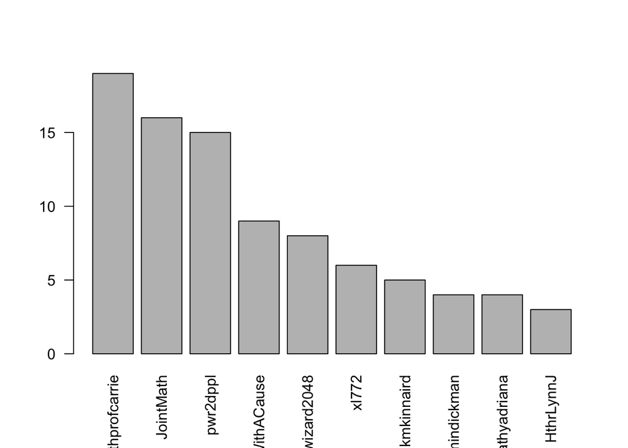

```
## [1] "gender"
```

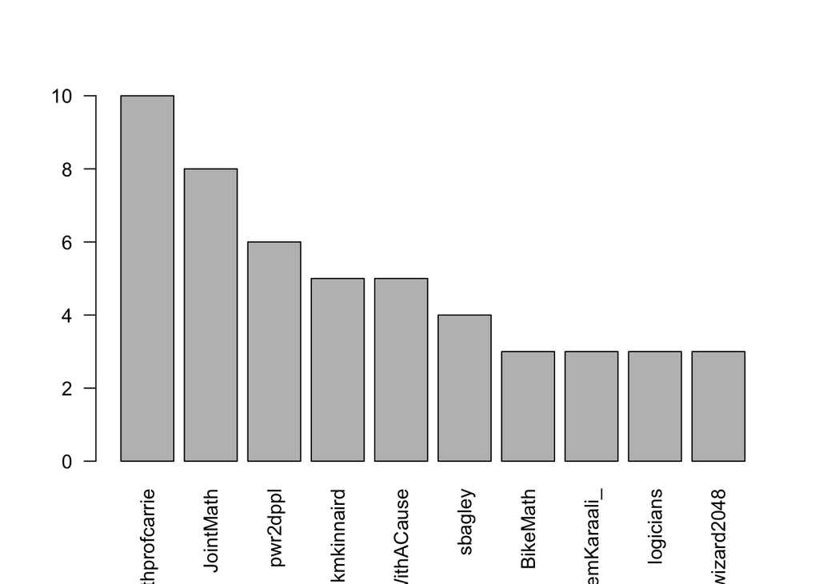

```
## [1] "indigenous"
```

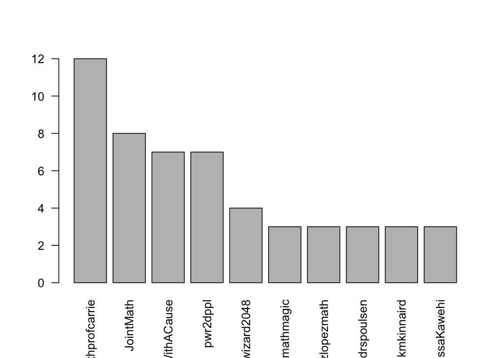

```
## [1] "advocacy"
```

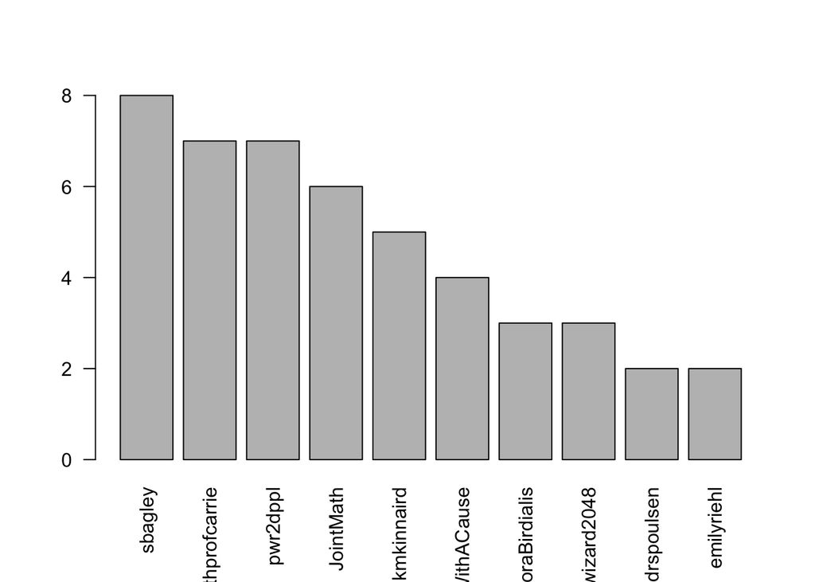

```
## [1] "power"
```

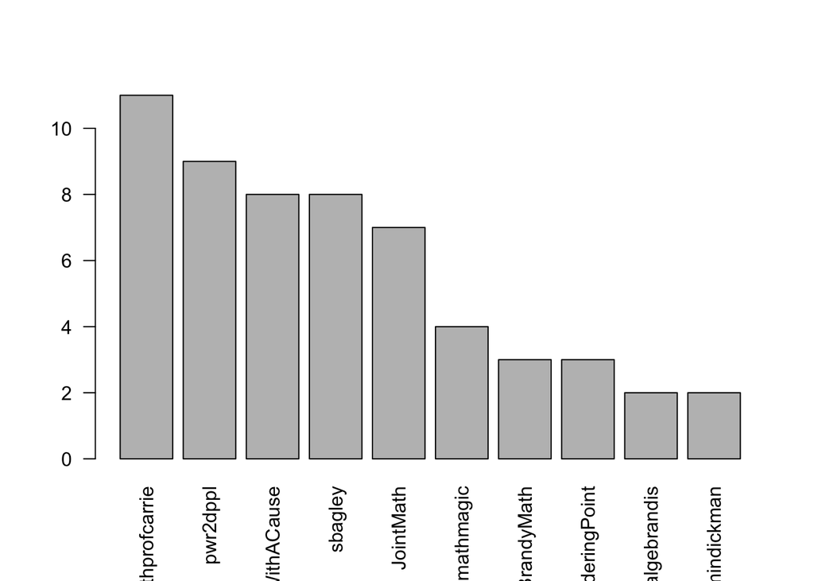

```
## [1] "bipoc"
```

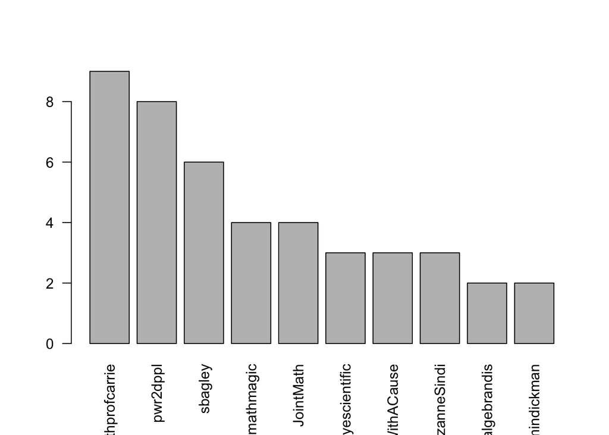

```r
important_codes <- c("representation","gender","indigenous","advocacy","power","bipoc")

for (code in important_codes){
  code_only <- filter(mt_edgelist, (!!as.symbol(code))=="True")
  print(code)
  top_tweeters=sort(table(code_only$Sender),decreasing=TRUE)
  #print(head(top_tweeters,10))
  barplot(head(top_tweeters,10),las=2)
}
```

# Active Tweeters

What were active tweeters doing. If you didn’t just RT things other people wrote. What were you talking about?

```r
#Remove everyone with indegree 0
#this removes RT and QT that no one else enaged with
active.peeps<-subset(indeg.peeps, !grepl(0,indeg.peeps))
#subset just these in the full data
active.edgelist <- subset(mt_edgelist, grepl(paste(names(active.peeps), collapse='|'), mt_edgelist$Receiver))
```

##Define network

```r
#create a matrix, just of Sender and Receiver
active.send_interact <- cbind(Sender = active.edgelist$Sender,Interactor = active.edgelist$Receiver)

# check it out
head(active.send_interact)
```

```
##      Sender            Interactor
## [1,] "mathprofcarrie"  "WanderingPoint"
## [2,] "mathprofcarrie"  "xl772"
## [3,] "RachelleDeCoste" "LoboWithACause"
## [4,] "RachelleDeCoste" "mathprofcarrie"
## [5,] "monsoon0"        "monsoon0"
## [6,] "fra_berni"       "fra_berni"
```

```r
dim(active.send_interact)
```

```
## [1] 816   2
```

### Define network from edgelist

```r
# make a graph object
activepeeps.g <- graph.edgelist(active.send_interact, directed = TRUE)
```

### Visualize the group network

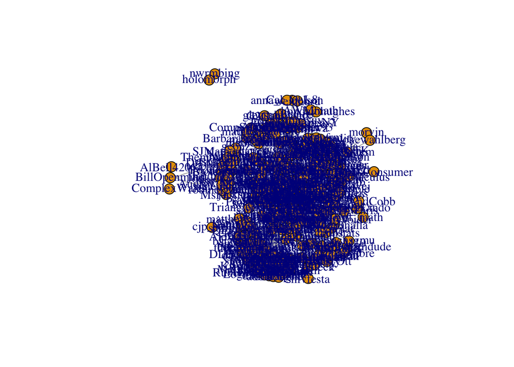

```r
#plot features
la <- layout_with_fr(activepeeps.g)
e.wt <- edge_attr(activepeeps.g, "weight")

#plot group network
plot(activepeeps.g, layout=la, vertex.size=10,edge.width=e.wt,vertex.label=V(activepeeps.g)$name, edge.arrow.size = .2)
```

```r
png("activepeople.png", width = 600, height = 600, units='mm', res = 600)
plot(activepeeps.g, layout=la, vertex.size=2,edge.width=e.wt,vertex.label=V(activepeeps.g)$name, edge.arrow.size = .2)
dev.off()
```

From this it seems like there are several people who are very well connected to each other (e.g. JointMath, pwr2dppl). Then there are people who are recruiting participation from outside the large interior cluster, engaging new networks (e.g. WanderingPoint, RG1gal, mathprofcarrie). Is this how this plays out in the modularity clusters?

# Modularity

```r
#modularity 0.1105  37 communities
wtc<-cluster_walktrap(mathpeeps.g)
#membership(wtc)
modularity(mathpeeps.g, membership(wtc))
```

```
## [1] 0.1105362
```

```r
#takes a while to run
#optc<-optimal.community(mathpeeps.g)

#gives like 312 communities with modularity 0.0637
#ceb <-edge.betweenness.community(mathpeeps.g, directed= TRUE)
#membership(ceb)
#modularity(mathpeeps.g, membership(ceb))

#gives 259 communities with a modularity of 0.0192
#lpc<-label.propagation.community(mathpeeps.g)
#membership(lpc)
#modularity(mathpeeps.g, membership(lpc))

#gives 10 communities with a modularity of 0.065
# this gives almost the same value as the 213 communities,
# but makes a lot more sense
infoc<-infomap.community(mathpeeps.g)
#membership(infoc)
modularity(mathpeeps.g, membership(infoc))
```

```
## [1] 0.07312318
```

```r
#connected components - 3 connected components
# modularity 0.0083
#compc<-components(mathpeeps.g)
#membership(compc)
#modularity(mathpeeps.g, membership(compc))
```